# Final_Project

Ethan Shoham

2026-04-20

Setup

Write Up

America’s Surprising Relationship with the Republic of Georgia

Using data from the United States Department of State, the World Bank, and the Varieties of Democracy data set, I created a social media style post to highlight the strangeness of how much foreign assistance the U.S. has sent to the Republic of Georgia in the 21st century. To this end, I extracted information from the U.S. Department of State about how much foreign assistance Georgia received from the U.S. each year and whether that assistance was for security or development purposes. I then compared Georgia’s foreign assistance receptions to those of countries strategically comparable with Georgia in the eyes of the U.S. to emphasize Georgia’s irregularity. Since Georgia is not resource rich or economically powerful, its primary strategic value to the U.S. comes from its size and its geographic location between Europe and Asia and near Russia. Therefore, I compared Georgia’s per capita foreign assistance receptions to countries of similar size and similar location as Georgia. My product is a social media style post to increase its potential appeal and reception. My target audience is a well-educated and politically engaged U.S. resident who may care about U.S. foreign policy but has no international relations or Georgia-specific expertise. Capitol Hill staffers I spoke to recently told me that they use social media at least as much as if not more than traditional news mediums, like newspapers and magazines, to communicate messages from their member of congress to the public and stay personally abreast of political happenings. I made my product a social media style post to tap into that trend and simulate the experience of trying to communicate persuasively with a lay political audience as closely as possible. My post intersperses text-laden slides with visuals to communicate the post’s central story, the irregularity of the U.S-Georgia relationship, while still making my visuals the center of attention. I began by textually introducing the puzzle the post tackles so that my inexpert audience would view my visuals through my desired lens. Having already established Georgia’s geographic location with my title slide, my first visual compares Georgia with countries of similar size to show how the country’s foreign assistance from the U.S. stands out from countries around the world. I chose to show 10 countries, Georgia and the nine countries with most similarly sized populations to it, because this number of countries accurately conveyed Georgia’s per capita assistance relative to other countries without cluttering the visual with too many dots or skewing the data with outliers such as micro-nations. I made comparison between Georgia and its peers easier by inserting a line representing the median per capita assistance by year for the 10 countries. My next text-based slide and visual breaks down the type of aid Georgia receives to begin explaining why Georgia receives its high quantity of aid from the U.S. Since this explanation centers on events tied to Georgia’s status as a post-Soviet state and location near Russia, this argument segways into my maps which compare Georgia’s development and security aid receptions to other post-Soviet states around Russia. My first two maps establish that Georgia is in the upper echelon of aid reception for a post-Soviet state for development and security before my final map shows that Georgia is in a league of its own when those two types of aid are summed together. This point was foreshadowed by and reinforces the title of my stacked bar plot. Finally, I show an anecdotal relationship between liberal democracy and U.S. aid reception to strengthen my explanation of why Georgia receives its high quantity of aid before concluding by acknowledging my uncertainty since it is presently unknown exactly why Georgia receives so much U.S. foreign assistance. Aesthetically, I endeavored to be true to an Instagram social media post given the service’s popularity with the age cohort of people newly in or about to enter the labor force. I put a short overview of my post in a text box below the slides, and I did not change the text between slides because that is impossible on Instagram. I also created arrows to navigate between slides and did not let viewers switch immediately from the last slide to the first slide or first slide to the last slide because that is also impossible on Instagram. I chose my color palette to show contrast clearly within the visuals but also to make my post match the slightly informal yet engaging environment of Instagram. Finally, I constrained my visuals to small 4x5 windows because that is the standard size of Instagram posts. This requirement forced me to be more efficient with my use of space but resulted in visuals aesthetically similar to what can be found on social media. The goal of my product is to convey the strangeness of the U.S-Georgia foreign assistance relationship to an engaged yet inexpert audience. My hope is that my aesthetic choices and combination of text and visuals produced a post that is educational without being very cognititvely taxing on its viewers.

Bar Chart

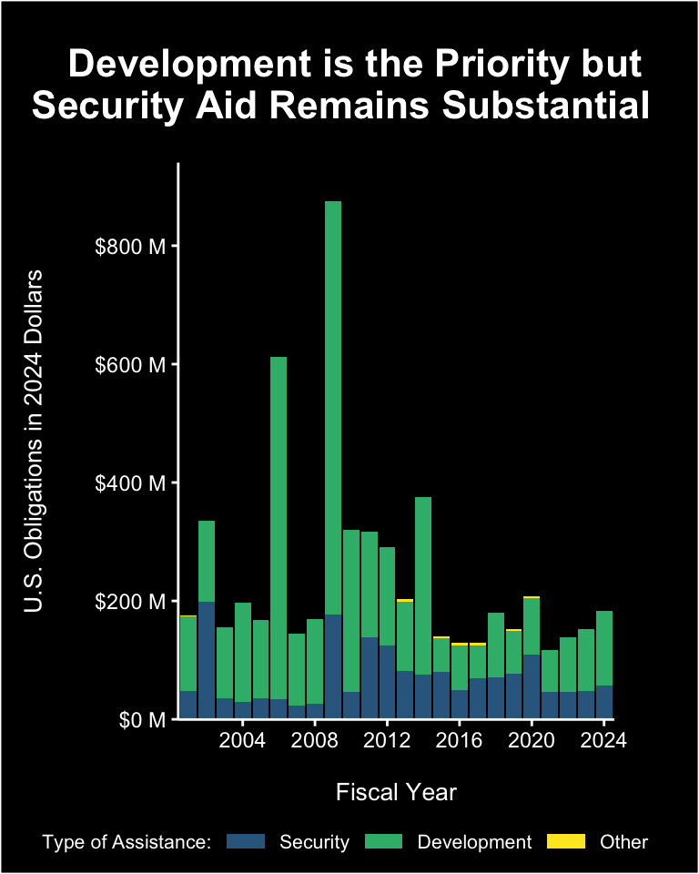

```r
# Assistance Breakdown

# This section cleans up the USG data to focus on just the years and country that I am interested in while also grouping the many possible USG sectors into a rough binary of security and development assistance. This binary makes my stacked bar chart easier to interpret.
dat_usg2 <- dat_usg |>
  filter(`Country Name` == "Georgia") |>
  filter(`Transaction Type Name` == "Obligations") |>
  filter(`Fiscal Year` != 2026) |>        # Excluded b/c only partial data available
  filter(`Fiscal Year` != 2025) |>        # Excluded b/c only partial data available
  mutate(combined_category = case_when(   # Combining traditional US sectors into two main groups
    stringr::str_detect(`US Category Name`,
                        "Economic Development|Education and Social Services|Health|Environment|Humanitarian Assistance|Democracy, Human Rights, and Governance|Program Support") ~ "Development",
    stringr::str_detect(`US Category Name`,
                        "Peace and Security") ~ "Security", TRUE ~ "Other"))|>
  group_by(`Fiscal Year`, combined_category) |>
  summarise(total_constant = sum(constant_amount, na.rm = TRUE), .groups = "drop")|>
  select(`Fiscal Year`, combined_category, total_constant)
dat_usg2$combined_category <- factor(dat_usg2$combined_category,
                                     levels = c("Other", "Development", "Security")) # Fixing the order of the categories

# These are the years for which all of my data sets have complete data
my_years <- seq(2001, 2024, 1)

# Finding the upper limit to fix my y axis labels
max_val_GE <- dat_fa |>
  filter(`Country Name` == "Georgia") |>
  filter(`Transaction Type Name` == "Obligations") |>
  filter(`Fiscal Year` %in% my_years) |> # Picking years where I have full data
  select(`Fiscal Year`, constant_amount) |>
  summarise(m = max(constant_amount, na.rm = T)) |>
  pull(m)

# Base plot
p <- ggplot(dat_usg2, aes(
  x = `Fiscal Year`,
  y  = total_constant,
  fill = combined_category))


my_plot <-
  p + geom_col(position = "stack") +
  scale_y_continuous(
    breaks = pretty(c(0, max_val_GE *1.1), n =4), # Extending the axis above my tallest bar
    labels = function(x) {      # Making my labels say $ and M instead of 6 zeros
      rounded_million <- round(x/ 1e6)
      paste0(scales::label_dollar()(rounded_million), " M")
    },
    expand = expansion(mult = c(0, 0.075)) # Wanted a little breathing room between the data and the axis
    ) +
  scale_x_continuous(
    breaks = seq(2004, 2024,
                 by = 4), # By four gives a good balance between being able to easily tell what year it is and not cluttering the visual
    expand = c(0.005, 0)) +
  labs(
    x = "Fiscal Year",
    y = "U.S. Obligations in 2024 Dollars",
    fill = "Type of Assistance:",
    title = "Development is the Priority but\nSecurity Aid Remains Substantial") +


# I use viridis' base colors here to maintain a consistent palette across my visuals
  scale_fill_manual(values = c(
    "Other" = "#FDE725",
    "Development" = "#35B779",
    "Security" = "#31688E"
  )) +

# Putting "other" as the last entry in my legend
  guides(
    fill = guide_legend(reverse = T)
  ) +

# I like to group my theme commands by what part of the plot they are affecting.
  theme(

    plot.title = element_text(
      hjust = 0.8,
      vjust = 1,
      face = "bold",
      size = 16,
      color = "white",
      margin = margin (b = 15)),
    plot.margin = margin(t = 20, r = 35, b = 10, l = 10, unit = "pt"),
    plot.background = element_rect(fill = "black"),

    panel.grid.minor = element_blank(),
    panel.grid.major = element_blank(),
    panel.background = element_rect(fill = "black"),
    panel.border = element_rect(fill = "white"),

    axis.title.x = element_text(
      margin = margin(t = 13),
      size = 10,
      color = "white"),
    axis.title.y = element_text(
      margin = margin(r = 20),
      size = 10,
      color = "white"),
    axis.text = element_text(
      color = "white"
    ),
    axis.line = element_line(
      color = "white"
    ),
    axis.ticks = element_line(color = "white"),

    legend.background = element_rect(fill = "black", color = "black", size = 0.5),
    legend.text = element_text(size = 8, color = "white"),
    legend.title = element_text(size = 8, color = "white"),
    legend.key.size = unit(0.1, "lines"),
    legend.key.width = unit(0.6, "cm"),
    legend.margin = margin(t = 0, r = 0, b = 0, l = 0, unit = "pt"),
    legend.position = "bottom",
    legend.justification = 0.8

    )
my_plot
```

```r
ggsave(filename = here("Final_Project", "www", "US_FA_GE_USG.png"), plot = my_plot, width = 4, height = 5, units = "in", dpi = 300)
```

Scatter Plots

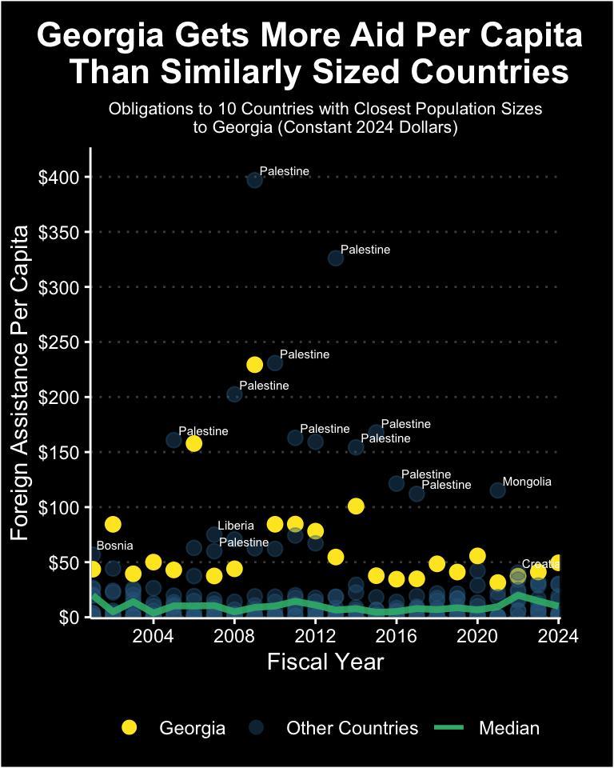

```r
# FA Per Capita Plot

my_years <- seq(2001, 2024, 1)

# Here I rename parts of my population data set in preparation for merging it with my other data sets.
pop_dat2 <- pop_dat |>
  select(TIME_PERIOD, OBS_VALUE, REF_AREA_LABEL) |>
  rename(`Fiscal Year` = TIME_PERIOD,
         `Country Name` = REF_AREA_LABEL,
         Population = OBS_VALUE)

# Here I focus in on obligations since I only care about U.S. sentiment towards Georgia in a given year and not so much about what assistance is actually able to make its way through the layers of complexity of execution and what year that happens.
dat_fa2 <- dat_fa |>
  mutate(`Fiscal Year` = as.integer(`Fiscal Year`)) |> # This was giving me trouble as a string
  select(`Country Name`, `Fiscal Year`, `constant_amount`, `Transaction Type Name`) |>
  filter(`Transaction Type Name` == "Obligations")
# This is just joining the population and foreign assistance data sets together and calculating a per capita value to allow easier comparisson between countries.
pop_dat3 <-
  left_join(dat_fa2,
            pop_dat2,
            by = c("Country Name", "Fiscal Year")) |>
  filter(`Fiscal Year` %in% my_years) |>
  drop_na() |>
  mutate(fa_ratio = (constant_amount/Population)) |> # Foreign assistance per capita to standardize across countries
  mutate(highlight = if_else(`Country Name` == "Georgia", "Georgia", "Other Countries"))

# 10 was arbitrarily chosen to maximize clarity for the visual. The trend displays holds true even with all countries depicted, but this approach makes the visual less cluttered. Additionally, it weeds out very large countries and very small countries and helps to control for tiers of countries that may receive different amounts of assistance for being in their tier (small, medium small, medium, medium large, large, etc.)
closest_10_per_yr <- pop_dat3 |>
  group_by(`Fiscal Year`) |>
  mutate(georgia_pop = Population[`Country Name` == "Georgia"][[1]]) |>
  mutate(pop_diff = abs(Population - georgia_pop),
         rank_closest = row_number(pop_diff)) |>
  filter(rank_closest <= 10) |>
  ungroup()

# I want to draw a median line for the 10 countries that I am showing to make Georgia's exceptional status more obvious. Median is a resistant statistic and will not be biased by outliers like mean.
med_by_year <- closest_10_per_yr |>
  group_by(`Fiscal Year`) |>
  summarise(median_fa = median(fa_ratio, na.rm = T), .groups = "drop")

# These lines of code exists so that I can see which countries received more assistance in a year than Georgia
georgia_by_year <- pop_dat3 |>
  filter(`Country Name` == "Georgia") |>
  select(`Fiscal Year`, georgia_fa = fa_ratio)

# And this is where I do that calculation
labels_df <- closest_10_per_yr |>
  left_join(georgia_by_year, by = "Fiscal Year") |>
  filter(fa_ratio > georgia_fa) |>
  mutate(`Country Name` = case_when(
    `Country Name` == "Bosnia and Herzegovina" ~ "Bosnia", # The original label was too large and was clipping out of my plot. The two or three letter country codes are probably unknown by my intended non-expert audience.
    `Country Name` == "West Bank and Gaza" ~ "Palestine", # Same here
    T ~ `Country Name`))


p2 <- ggplot(
  data = closest_10_per_yr,
             aes(
               x = `Fiscal Year`,
               y = fa_ratio,
               color = highlight, # Making Georgia pop from the other countries
               alpha = highlight, # Making Georgia pop even more
               text = `Country Name`)) +

  geom_point(
    size = 3
  ) +

  geom_text(
    data = labels_df,
    aes(
      x = `Fiscal Year`,
      y = fa_ratio,
      label = `Country Name`), # I wanted to highlight the few countries that exceed Georgia to put it in context for my viewers. I think that its similarity to Palestine in particular will be shocking.
    color = "white",
    size = 2,
    vjust = -0.6,
    hjust = -0.10,
    check_overlap = T,
    inherit.aes = F
  ) +

  geom_line( # Making that median line
    data = med_by_year,
    aes(x = `Fiscal Year`,
        y = median_fa,
    color = "Median"),
    linetype = "solid",
    size = 1.5,
    alpha = 0.9,
    inherit.aes = F) +

  # Using viridis colors again to ensure consistency across the post
  scale_color_manual(
    name = NULL,
    breaks = c("Georgia", "Other Countries", "Median"),
    labels = c("Georgia", "Other Countries", "Median"),
    values = c(
      "Georgia" = "#FDE725",
      "Other Countries" = "#31688E",
      "Median" = "#35B779"
    )
  ) +
  scale_alpha_manual(values = c("Georgia" = 1, # Making Georgia pop even more
                                "Other Countries" = 0.4,
                                "Median" = 1),
                     guide = "none"
                     ) +
  guides(
    color = guide_legend(
      override.aes = list(
        linetype = c(0, 0, 1),
        shape = c(16, 16, NA),
        linewidth = c(0, 0.8, 1), # Making the media appear as a line in the legend
        alpha = c(1, 0.4, 1) # Making the legend accurate to the opacity of the other countries' data representations
      )
    )
  ) +

  coord_cartesian(xlim = c(2001, 2024), clip = "on") +

  scale_x_continuous(breaks = seq(2004, 2024, by = 4),
                     expand = c(0.005, 0)) +
  scale_y_continuous(
    labels = label_dollar(),
    breaks = seq(0, 400, by = 50),
    expand = expansion(mult = c(0, 0.075)
  )) +

  theme(

    panel.grid.major.y = element_line(
      color = "gray30",
      linetype = "dotted" # Making my grid lines a little less distracting
    ),
    panel.grid.minor.y = element_blank(),
    panel.grid.major.x = element_blank(),
    panel.grid.minor.x = element_blank(),

    axis.title.x = element_text(color = "white"),
    axis.title.y = element_text(color = "white"),
    axis.text = element_text(color = "white"),
    axis.ticks = element_line(color = "white"),
    axis.line = element_line(color = "white"),

    plot.title = element_text(
      size = 16,
      hjust = 0.7,
      vjust = 0.95,
      face = "bold",
      color = "white"),

    plot.subtitle = element_text(
      size = 8,
      hjust = 0.5,
      vjust = 0.85,
      color = "white"),

    plot.margin = margin(t = 10, r = 25, b = 5, l = 5, unit = "pt"),


    panel.background = element_rect(fill = "black"), # So handy :)
    plot.background = element_rect(fill = "black"),
    panel.border = element_rect(color = "black"),

    legend.background = element_rect(fill = "black"),
    legend.title = element_text(color = "white"),
    legend.text = element_text(color = "white"),
    legend.position = "bottom",
    legend.box.margin = margin(t = 0, r = 0, b = 0, l = 0, unit = "pt")
  ) +

  labs(title = "Georgia Gets More Aid Per Capita\nThan Similarly Sized Countries",
       subtitle = "Obligations to 10 Countries with Closest Population Sizes\nto Georgia (Constant 2024 Dollars)",
       x = "Fiscal Year",
       y = "Foreign Assistance Per Capita",
       )
p2
```

```r
ggsave(filename = here("Final_Project", "www", "Per_Capita.png"), plot = p2, width = 4, height = 5, units = "in", dpi = 300)
```

```r
# Democracy

my_years2 <- seq(2001, 2021, 1)      # After experimentation, this range covered the most amount of time without skewing the trend of US assistance to Ukraine (and therefore the whole color palette) due to US aid to Ukraine for its war with Russia. For the 20 years through 2021 (including 2014), Ukraine received low assistance per capita, but by 2024, its assistance per capita was so high that even Georgia was not yellow anymore.

postSoviet <- c("Estonia", "Latvia", "Lithuania", "Belarus", "Ukraine", "Moldova", "Georgia", "Armenia", "Azerbaijan", "Kazakhstan", "Uzbekistan", "Turkmenistan", "Kyrgyzstan", "Tajikistan", "Mongolia", "Finland")

og_vdem <- readRDS(here("Data_Sets", "vdem15.rds"))

vdem <- og_vdem |>
  filter(country_name %in% postSoviet) |>
  filter(year %in% my_years2) |>
  mutate(`Fiscal Year` = year) |>
  mutate(`Country Name` = country_name) |>
  select(`Country Name`, `Fiscal Year`, v2x_libdem)

pop_dat2 <- pop_dat |>
  select(TIME_PERIOD, OBS_VALUE, REF_AREA_LABEL) |>
  rename(`Fiscal Year` = TIME_PERIOD,
         `Country Name` = REF_AREA_LABEL,
         Population = OBS_VALUE)


dat_fa3 <- dat_fa |>
  mutate(`Fiscal Year` = as.integer(`Fiscal Year`)) |>
  select(`Country Name`, `Fiscal Year`, `constant_amount`, `Transaction Type Name`) |>
  filter(`Transaction Type Name` == "Obligations") |>
  filter(`Country Name` %in% postSoviet)
```

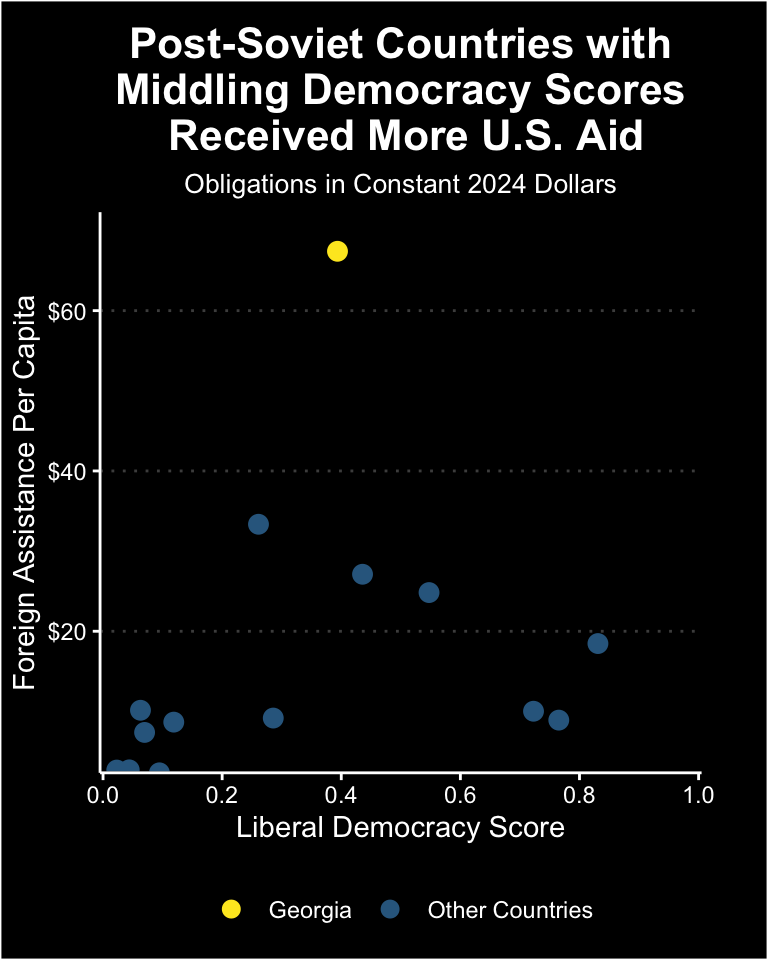

```r
pop_dat4 <-
  left_join(dat_fa3,
            pop_dat2,
            by = c("Country Name", "Fiscal Year")) |>
  filter(`Fiscal Year` %in% my_years2) |>
  drop_na() |>
  mutate(fa_ratio = (constant_amount/Population)) |>
  mutate(highlight = if_else(`Country Name` == "Georgia", "Georgia", "Other Countries")) |>
  filter(`Country Name` != "Finland")

postSovietDat <- pop_dat4 |>
    filter(`Country Name` %in% postSoviet) |>
    filter(`Fiscal Year` %in% my_years2)

postSovietDem <-
  left_join(postSovietDat,
            vdem,
            by = c("Country Name", "Fiscal Year")) |>
  select(`Country Name`, `Fiscal Year`, `fa_ratio`, v2x_libdem, highlight)


georgia_by_year2 <- postSovietDem |>
  filter(`Country Name` == "Georgia")

avg_oblig2 <- postSovietDem |>
  group_by(`Country Name`) |>
  summarise(
    avg_obligpc = mean(fa_ratio, na.rm = T),
    .groups = "drop"
  )

avg_dem <- postSovietDem |>
  group_by(`Country Name`) |>
  summarise(
    avg_dem = mean(v2x_libdem, na.rm = T),
    .groups = "drop"
  )

avg_postSoviet <-
  left_join(
    avg_oblig2,
    avg_dem,
    by = "Country Name") |>
  mutate(highlight = if_else(`Country Name` == "Georgia", "Georgia", "Other Countries"))

max_val2 <- avg_postSoviet |> # Finding the upper limit to fix my y axis labels
  summarise(m = max(avg_obligpc, na.rm = T)) |>
  pull(m)



p2 <- ggplot(
  data = avg_postSoviet,
             aes(
               x = `avg_dem`,
               y = avg_obligpc,
               color = highlight # Making Georgia a different color like before
               )) +

  geom_point(
    size = 3
  ) +

  scale_color_manual(
    name = NULL,
    breaks = c("Georgia", "Other Countries"),
    labels = c("Georgia", "Other Countries"),
    values = c(
      "Georgia" = "#FDE725",
      "Other Countries" = "#31688E"
    )
  ) +
  scale_alpha_manual(values = c("Georgia" = 1,
                                "Other Countries" = 1),
                     guide = "none"
                     ) +
  guides(
    color = guide_legend(
      override.aes = list(
        shape = c(16, 16),
        alpha = c(1, 1) # I am showing so few entries besides Georgia this time since I am not going year by year, so I need my other countries to be fully opaque if I want them to be visible enough to be compared with Georgia.
      )
    )
  ) +

  coord_cartesian(xlim = c(0, 1), clip = "on") +

  scale_x_continuous(breaks = seq(0, 1, by = 0.2),
                     expand = c(0.005, 0)) +
  scale_y_continuous(
    labels = label_dollar(),
    breaks = pretty(c(0, max_val2 *1.1), n = 5),
    expand = expansion(mult = c(0, 0.075))
  ) +

  theme(

    panel.grid.major.y = element_line(
      color = "gray30",
      linetype = "dotted"
    ),
    panel.grid.minor.y = element_blank(),
    panel.grid.major.x = element_blank(),
    panel.grid.minor.x = element_blank(),

    axis.title.x = element_text(color = "white"),
    axis.title.y = element_text(color = "white"),
    axis.text = element_text(color = "white"),
    axis.ticks = element_line(color = "white"),
    axis.line = element_line(color = "white"),

    plot.title = element_text(
      size = 16,
      hjust = 0.5,
      vjust = 0.95,
      face = "bold",
      color = "white"),

    plot.subtitle = element_text(size = 10, hjust = 0.5, vjust = 0.85, color = "white"),
    plot.margin = margin(t = 10, r = 25, b = 5, l = 5, unit = "pt"),


    panel.background = element_rect(fill = "black"), # So handy :)
    plot.background = element_rect(fill = "black"),
    panel.border = element_rect(color = "black"),

    legend.background = element_rect(fill = "black"),
    legend.title = element_text(color = "white"),
    legend.text = element_text(color = "white"),
    legend.position = "bottom",
    legend.box.margin = margin(t = 0, r = 0, b = 0, l = 0, unit = "pt")
  ) +

  labs(title = "Post-Soviet Countries with\nMiddling Democracy Scores\n Received More U.S. Aid",
       subtitle = "Obligations in Constant 2024 Dollars",
       x = "Liberal Democracy Score",
       y = "Foreign Assistance Per Capita",
       )
p2
```

```r
ggsave(filename = here("Final_Project", "www", "Democracy.png"), plot = p2, width = 4, height = 5, units = "in", dpi = 300)
```

Maps

```r
# Map Time -- Foreign Assistance per Capita

# Isolating Region of Interest --> change name to my_countries
postSoviet <- c("Estonia", "Latvia", "Lithuania", "Belarus", "Ukraine", "Moldova", "Georgia", "Armenia", "Azerbaijan", "Kazakhstan", "Uzbekistan", "Turkmenistan", "Kyrgyzstan", "Tajikistan", "Mongolia", "Finland")


my_years2 <- seq(2001, 2021, 1)      # After experimentation, this range covered the most amount of time without skewing the trend of US assistance to Ukraine (and therefore the whole color palette) due to US aid to Ukraine for its war with Russia. For the 20 years through 2021 (including 2014), Ukraine received low assistance per capita, but by 2024, its assistance per capita was so high that even Georgia was not yellow anymore.


pop_dat2 <- pop_dat |>
  select(TIME_PERIOD, OBS_VALUE, REF_AREA_LABEL) |>
  rename(`Fiscal Year` = TIME_PERIOD,
         `Country Name` = REF_AREA_LABEL,
         Population = OBS_VALUE)


dat_fa2 <- dat_fa |>
  mutate(`Fiscal Year` = as.integer(`Fiscal Year`)) |>
  select(`Country Name`,
         `Fiscal Year`,
         `constant_amount`,
         `Transaction Type Name`) |>
  filter(`Transaction Type Name` == "Obligations")
pop_dat3 <-
  left_join(dat_fa2,
            pop_dat2,
            by = c("Country Name", "Fiscal Year")) |>
  filter(`Fiscal Year` %in% my_years2) |>
  drop_na() |>
  mutate(fa_ratio = (constant_amount/Population)) # Getting that per capita again

# Making a data set of only my region of interest
postSovietDat <- pop_dat3 |>
    filter(`Country Name` %in% postSoviet) |>
    filter(`Fiscal Year` %in% my_years2)

# Averaging across years
avg_oblig <- postSovietDat |>
  group_by(`Country Name`) |>
  summarise(
    avg_ratio = mean(fa_ratio, na.rm = T),
    .groups = "drop"
  )


# Now let's draw our map of Post Soviet countries. Since I want to do a choropleth map, I want to do a point map.

# Loading the environment pointer
data("worldMapEnv", package = "maps")

# Extracting the world polygons as a data frame
world_map <- maps::map("world", plot = F, fill = T)

class(world_map)
```

```
## [1] "map"
```

```r
# Map Polygons
world_df <- map_data("world")

head(world_df)
```

```
##        long      lat group order region subregion
## 1 -69.89912 12.45200     1     1  Aruba      <NA>
## 2 -69.89571 12.42300     1     2  Aruba      <NA>
## 3 -69.94219 12.43853     1     3  Aruba      <NA>
## 4 -70.00415 12.50049     1     4  Aruba      <NA>
## 5 -70.06612 12.54697     1     5  Aruba      <NA>
## 6 -70.05088 12.59707     1     6  Aruba      <NA>
```

```r
# Renaming region to Country in world_df for pairing purposes
postSoviet_map <- world_df |>
    mutate(`Country Name` = region)

# Making the DF more specific
postSoviet_map <- postSoviet_map |>
    filter(`Country Name` %in% postSoviet)


# Checking for different names
setdiff(unique(postSoviet_map$region), unique(postSovietDat$`Country Name`))
```

```
## [1] "Kyrgyzstan"
```

```r
setdiff(unique(postSovietDat$`Country Name`), unique(postSoviet_map$region))
```

```
## character(0)
```

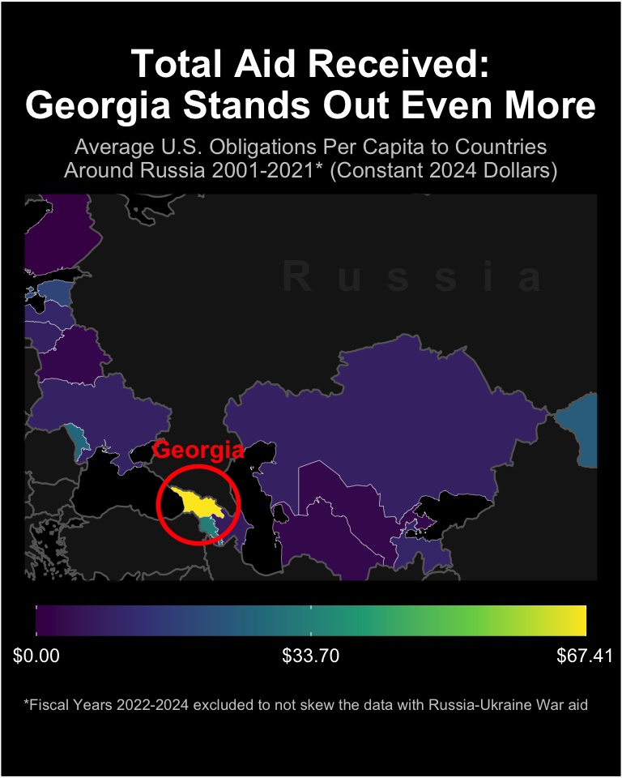

```r
# Merging
map_data <- avg_oblig |>
  left_join(postSoviet_map, by = "Country Name")

# I create this to be able to put a maximum value for my legend
max_val <- map_data |>
  filter(`Country Name` %in% postSoviet) |>
  summarise(m = max(avg_ratio, na.rm = T)) |>
  pull(m)

# This is the data for all of the non-post-Soviet countries that will be included to help the view understand where the map is but will not be colored in so as to not be distracting.
russia_dat <- world_df |>
  filter(!region %in% postSoviet)

# I use these latter to draw a circle around Georgia to highlight it for people who do not know where it is on a map.
georgia_lon <- 43.5
georgia_lat <- 42.1


# Now for the actual visual
p3 <- ggplot(map_data, aes(x = long,
                           y = lat,
                           fill = avg_ratio,
                           group = group)) +
   geom_polygon(color = "gray90", linewidth = .1) +
   geom_polygon(
    data = russia_dat,
    aes(x = long, y = lat, group = group),
    fill = "gray10",
    color = "gray40",# Making all countries besides my region of interest the least distracting possible
    linewidth = 0.4
  ) +

  # Circling Georgia
  annotate(
    "path",
    x = georgia_lon + 5 * cos(seq(0, 2*pi, length.out = 200)),
    y = georgia_lat + 3 * sin(seq(0, 2*pi, length.out = 200)),
    color = "red",
    linewidth = 1
  ) +

  annotate( # Labeling Georgia
    "text",
    x = 43.5,
    y = 46.5,
    label = "Georgia",
    color = "red",
    fontface = "bold",
    size = 4,
    label.size = 0.30
  ) +

  annotate( # Subtly labeling Russia to help viewers orient themselves on the map without distracting themselves too much for Georgia
    "text",
    x = 70,
    y = 60,
    label = "R  u  s  s  i  a",
    color = "gray80",
    alpha = 0.075,
    fill = NA,
    fontface = "bold",
    size = 7,
    label.size = 0.25
  ) +

  # Fixing my color palette scale
  scale_fill_viridis_c(
    limits = c(0, max_val),
    breaks = seq(0, max_val, length.out = 3),
    labels = scales::label_dollar()


    ) +
  # Framing my map
        coord_quickmap(
          xlim = c(25, 90),
          ylim = c(37.5, 65)) +

   theme(

          panel.grid = element_blank(),

          axis.ticks = element_blank(),
          axis.title = element_blank(),
          axis.text = element_blank(),

          panel.background = element_rect(fill = "black"),
          panel.border = element_rect(color = "black", fill = NA),

          strip.background = element_rect(fill = "black"),
          strip.text = element_text(face = "bold", color = "black"),

          plot.background = element_rect(fill = "black"),
          plot.margin = margin(t = 22, r = 11, b = 30, l = 11, unit = "pt"),
          plot.title = element_text(
            size = 18,
            hjust = 0.5,
            vjust = 0.95,
            face = "bold",
            color = "white"),

    plot.subtitle = element_text(size = 10, hjust = 0.5, vjust = 0.9, color = "gray80"),
    plot.caption = element_text(color = "gray80", size = 7, hjust = 0),

          legend.background = element_rect(fill = "black"),
          legend.title = element_blank(),
          legend.margin = margin(t = 0, r = 0, b = 10, l = 0, unit = "pt"),
          legend.key.height = unit(0.5, "cm"),
          legend.position = "bottom",
    legend.text = element_text(color = "white"),
    legend.key.size = unit(0.6, "lines"),
    legend.key.width = unit(1.80, "cm"),

              ) +
labs(title = "Total Aid Received:\nGeorgia Stands Out Even More",
       subtitle = "Average U.S. Obligations Per Capita to Countries\nAround Russia 2001-2021* (Constant 2024 Dollars)",
     caption = "*Fiscal Years 2022-2024 excluded to not skew the data with Russia-Ukraine War aid"
       )
p3
```

```r
ggsave(filename = here("Final_Project", "www", "Map.png"), plot = p3, width = 4, height = 5, units = "in", dpi = 300)
```

```r
# Map Time -- Only Development Foreign Assistance per Capita

# Isolating Region of Interest

postSoviet <- c("Estonia", "Latvia", "Lithuania", "Belarus", "Ukraine", "Moldova", "Georgia", "Armenia", "Azerbaijan", "Kazakhstan", "Uzbekistan", "Turkmenistan", "Kyrgyzstan", "Tajikistan", "Mongolia", "Finland")


my_years2 <- seq(2001, 2021, 1)      # After experimentation, this range covered the most amount of time without skewing the trend of US assistance to Ukraine (and therefore the whole color palette) due to US aid to Ukraine for its war with Russia. For the 20 years through 2021 (including 2014), Ukraine received low assistance per capita, but by 2024, its assistance per capita was so high that even Georgia was not yellow anymore.


pop_dat2 <- pop_dat |>
  select(TIME_PERIOD, OBS_VALUE, REF_AREA_LABEL) |>
  rename(`Fiscal Year` = TIME_PERIOD,
         `Country Name` = REF_AREA_LABEL,
         Population = OBS_VALUE)


dat_usg3 <- dat_usg |>
  mutate(`Fiscal Year` = as.integer(`Fiscal Year`)) |>
  filter(`Country Name` %in% postSoviet) |>
  filter(`Transaction Type Name` == "Obligations") |>
  filter(`Fiscal Year` %in% my_years2) |>
  mutate(combined_category = case_when(   # Combining traditional US sectors into two main groups
    stringr::str_detect(`US Category Name`,
                        "Economic Development|Education and Social Services|Health|Environment|Humanitarian Assistance|Democracy, Human Rights, and Governance|Program Support") ~ "Development",
    stringr::str_detect(`US Category Name`,
                        "Peace and Security") ~ "Security", TRUE ~ "Other"))|>
  filter(combined_category == "Development") |> # I want to only focus on development assistance data here.
  select(`Country Name`, `Fiscal Year`, `constant_amount`, `Transaction Type Name`, combined_category)



pop_dat3 <-
  left_join(dat_usg3,
            pop_dat2,
            by = c("Country Name", "Fiscal Year")) |>
  filter(`Fiscal Year` %in% my_years2) |>
  drop_na() |>
  mutate(fa_ratio = (constant_amount/Population))

postSovietDat <- pop_dat3 |>
    filter(`Country Name` %in% postSoviet) |>
    filter(`Fiscal Year` %in% my_years2)

avg_oblig <- postSovietDat |>
  group_by(`Country Name`) |>
  summarise(
    avg_ratio = mean(fa_ratio, na.rm = T),
    .groups = "drop"
  )



# Now let's draw our map of Post Soviet countries. Since I want to do a choropleth map, I want to do a point map.

# Loading the environment pointer
data("worldMapEnv", package = "maps")

# Extracting the world polygons as a data frame
world_map <- maps::map("world", plot = F, fill = T)

class(world_map)
```

```
## [1] "map"
```

```r
# Map Polygons
world_df <- map_data("world")

head(world_df)
```

```
##        long      lat group order region subregion
## 1 -69.89912 12.45200     1     1  Aruba      <NA>
## 2 -69.89571 12.42300     1     2  Aruba      <NA>
## 3 -69.94219 12.43853     1     3  Aruba      <NA>
## 4 -70.00415 12.50049     1     4  Aruba      <NA>
## 5 -70.06612 12.54697     1     5  Aruba      <NA>
## 6 -70.05088 12.59707     1     6  Aruba      <NA>
```

```r
# Renaming region to Country in world_df for pairing purposes
postSoviet_map <- world_df |>
    mutate(`Country Name` = region)

# Making the DF more specific
postSoviet_map <- postSoviet_map |>
    filter(`Country Name` %in% postSoviet)


# Checking for different names
setdiff(unique(postSoviet_map$region), unique(postSovietDat$`Country Name`))
```

```
## [1] "Kyrgyzstan"
```

```r
setdiff(unique(postSovietDat$`Country Name`), unique(postSoviet_map$region))
```

```
## character(0)
```

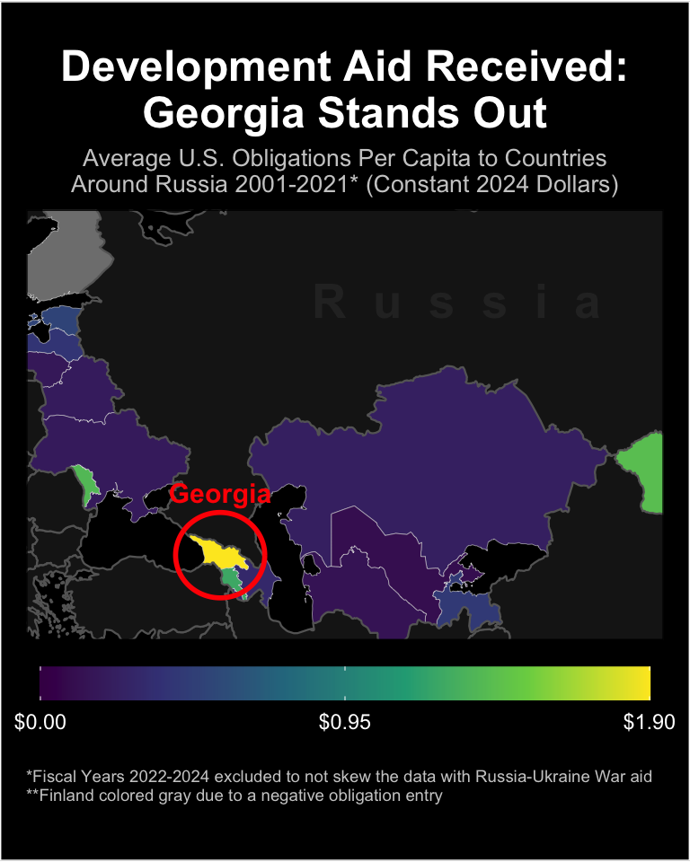

```r
# Merging
map_data <- avg_oblig |>
  left_join(postSoviet_map, by = "Country Name")

max_val <- map_data |>
  filter(`Country Name` %in% postSoviet) |>
  summarise(m = max(avg_ratio, na.rm = T)) |>
  pull(m)

russia_dat <- world_df |>
  filter(!region %in% postSoviet)

georgia_lon <- 43.5
georgia_lat <- 42.1


# Now for the actual visual
p3 <- ggplot(map_data, aes(x = long,
                           y = lat,
                           fill = avg_ratio,
                           group = group)) +
   geom_polygon(color = "gray90", linewidth = .1) +
   geom_polygon(
    data = russia_dat,
    aes(x = long, y = lat, group = group),
    fill = "gray10",
    color = "gray40",
    linewidth = 0.4
  ) +

  annotate(
    "path",
    x = georgia_lon + 5 * cos(seq(0, 2*pi, length.out = 200)),
    y = georgia_lat + 3 * sin(seq(0, 2*pi, length.out = 200)),
    color = "red",
    linewidth = 1
  ) +

  annotate(
    "text",
    x = 43.5,
    y = 46.5,
    label = "Georgia",
    color = "red",
    fontface = "bold",
    size = 4,
    label.size = 0.30
  ) +

  annotate(
    "text",
    x = 70,
    y = 60,
    label = "R  u  s  s  i  a",
    color = "gray80",
    alpha = 0.075,
    fill = NA,
    fontface = "bold",
    size = 7,
    label.size = 0.25
  ) +

  scale_fill_viridis_c(
    limits = c(0, max_val),
    breaks = seq(0, max_val, length.out = 3),
    labels = scales::label_dollar()


    ) +
        coord_quickmap(
          xlim = c(25, 90),
          ylim = c(37.5, 65)) +

   theme(

          panel.grid = element_blank(),

          axis.ticks = element_blank(),
          axis.title = element_blank(),
          axis.text = element_blank(),

          panel.background = element_rect(fill = "black"),
          panel.border = element_rect(color = "black", fill = NA),

          strip.background = element_rect(fill = "black"),
          strip.text = element_text(face = "bold", color = "black"),

          plot.background = element_rect(fill = "black"),
          plot.margin = margin(t = 20, r = 11, b = 24, l = 11, unit = "pt"),

          plot.title = element_text(
            size = 18,
            hjust = 0.5,
            vjust = 0.95,
            face = "bold",
            color = "white"),

    plot.subtitle = element_text(size = 10, hjust = 0.5, vjust = 0.9, color = "gray80"),
    plot.caption = element_text(color = "gray80", size = 7, hjust = 0),

          legend.background = element_rect(fill = "black"),
          legend.title = element_blank(),
          legend.margin = margin(t = 0, r = 0, b = 10, l = 0, unit = "pt"),
          legend.key.height = unit(0.5, "cm"),
          legend.position = "bottom",
    legend.text = element_text(color = "white"),
    legend.key.size = unit(0.6, "lines"),
    legend.key.width = unit(1.80, "cm"),

              ) +
labs(title = "Development Aid Received:\nGeorgia Stands Out",
       subtitle = "Average U.S. Obligations Per Capita to Countries\nAround Russia 2001-2021* (Constant 2024 Dollars)",
     caption = "*Fiscal Years 2022-2024 excluded to not skew the data with Russia-Ukraine War aid\n**Finland colored gray due to a negative obligation entry"
       )
p3
```

```r
ggsave(filename = here("Final_Project", "www", "Map2.png"), plot = p3, width = 4, height = 5, units = "in", dpi = 300)
```

```r
# Map Time -- Peace and Security Foreign Assistance per Capita

# Isolating Region of Interest

postSoviet <- c("Estonia", "Latvia", "Lithuania", "Belarus", "Ukraine", "Moldova", "Georgia", "Armenia", "Azerbaijan", "Kazakhstan", "Uzbekistan", "Turkmenistan", "Kyrgyzstan", "Tajikistan", "Mongolia", "Finland")


my_years2 <- seq(2001, 2021, 1)      # After experimentation, this range covered the most amount of time without skewing the trend of US assistance to Ukraine (and therefore the whole color palette) due to US aid to Ukraine for its war with Russia. For the 20 years through 2021 (including 2014), Ukraine received low assistance per capita, but by 2024, its assistance per capita was so high that even Georgia was not yellow anymore.


pop_dat2 <- pop_dat |>
  select(TIME_PERIOD, OBS_VALUE, REF_AREA_LABEL) |>
  rename(`Fiscal Year` = TIME_PERIOD,
         `Country Name` = REF_AREA_LABEL,
         Population = OBS_VALUE)


dat_usg3 <- dat_usg |>
  mutate(`Fiscal Year` = as.integer(`Fiscal Year`)) |>
  filter(`Country Name` %in% postSoviet) |>
  filter(`Transaction Type Name` == "Obligations") |>
  filter(`Fiscal Year` %in% my_years2) |>
  mutate(combined_category = case_when(   # Combining traditional US sectors into two main groups
    stringr::str_detect(`US Category Name`,
                        "Economic Development|Education and Social Services|Health|Environment|Humanitarian Assistance|Democracy, Human Rights, and Governance|Program Support") ~ "Development",
    stringr::str_detect(`US Category Name`,
                        "Peace and Security") ~ "Security", TRUE ~ "Other"))|>
  filter(combined_category == "Security") |> # I want to only focus on security assistance data here.
  select(`Country Name`, `Fiscal Year`, `constant_amount`, `Transaction Type Name`, combined_category)



pop_dat3 <-
  left_join(dat_usg3,
            pop_dat2,
            by = c("Country Name", "Fiscal Year")) |>
  filter(`Fiscal Year` %in% my_years2) |>
  drop_na() |>
  mutate(fa_ratio = (constant_amount/Population))

postSovietDat <- pop_dat3 |>
    filter(`Country Name` %in% postSoviet) |>
    filter(`Fiscal Year` %in% my_years2)

avg_oblig <- postSovietDat |>
  group_by(`Country Name`) |>
  summarise(
    avg_ratio = mean(fa_ratio, na.rm = T),
    .groups = "drop"
  )



# Now let's draw our map of Post Soviet countries. Since I want to do a choropleth map, I want to do a point map.

# Loading the environment pointer
data("worldMapEnv", package = "maps")

# Extracting the world polygons as a data frame
world_map <- maps::map("world", plot = F, fill = T)

class(world_map)
```

```
## [1] "map"
```

```r
# Map Polygons
world_df <- map_data("world")

head(world_df)
```

```
##        long      lat group order region subregion
## 1 -69.89912 12.45200     1     1  Aruba      <NA>
## 2 -69.89571 12.42300     1     2  Aruba      <NA>
## 3 -69.94219 12.43853     1     3  Aruba      <NA>
## 4 -70.00415 12.50049     1     4  Aruba      <NA>
## 5 -70.06612 12.54697     1     5  Aruba      <NA>
## 6 -70.05088 12.59707     1     6  Aruba      <NA>
```

```r
# Renaming region to Country in world_df for pairing purposes
postSoviet_map <- world_df |>
    mutate(`Country Name` = region)

# Making the DF more specific
postSoviet_map <- postSoviet_map |>
    filter(`Country Name` %in% postSoviet)


# Checking for different names
setdiff(unique(postSoviet_map$region), unique(postSovietDat$`Country Name`))
```

```
## [1] "Kyrgyzstan"
```

```r
setdiff(unique(postSovietDat$`Country Name`), unique(postSoviet_map$region))
```

```
## character(0)
```

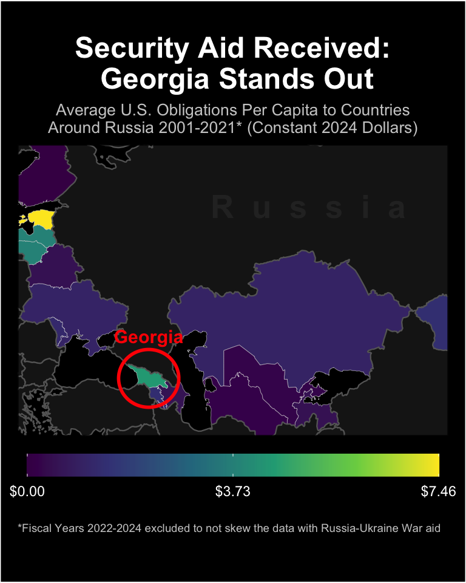

```r
# Merging
map_data <- avg_oblig |>
  left_join(postSoviet_map, by = "Country Name")

max_val <- map_data |>
  filter(`Country Name` %in% postSoviet) |>
  summarise(m = max(avg_ratio, na.rm = T)) |>
  pull(m)

russia_dat <- world_df |>
  filter(!region %in% postSoviet)

georgia_lon <- 43.5
georgia_lat <- 42.1


# Now for the actual visual
p3 <- ggplot(map_data, aes(x = long,
                           y = lat,
                           fill = avg_ratio,
                           group = group)) +
   geom_polygon(color = "gray90", linewidth = .1) +
   geom_polygon(
    data = russia_dat,
    aes(x = long, y = lat, group = group),
    fill = "gray10",
    color = "gray40",
    linewidth = 0.4
  ) +

  annotate(
    "path",
    x = georgia_lon + 5 * cos(seq(0, 2*pi, length.out = 200)),
    y = georgia_lat + 3 * sin(seq(0, 2*pi, length.out = 200)),
    color = "red",
    linewidth = 1
  ) +

  annotate(
    "text",
    x = 43.5,
    y = 46.5,
    label = "Georgia",
    color = "red",
    fontface = "bold",
    size = 4,
    label.size = 0.30
  ) +

  annotate(
    "text",
    x = 70,
    y = 60,
    label = "R  u  s  s  i  a",
    color = "gray80",
    alpha = 0.075,
    fill = NA,
    fontface = "bold",
    size = 7,
    label.size = 0.25
  ) +

  scale_fill_viridis_c(
    limits = c(0, max_val),
    breaks = seq(0, max_val, length.out = 3),
    labels = scales::label_dollar()


    ) +
        coord_quickmap(
          xlim = c(25, 90),
          ylim = c(37.5, 65)) +

   theme(

          panel.grid = element_blank(),

          axis.ticks = element_blank(),
          axis.title = element_blank(),
          axis.text = element_blank(),

          panel.background = element_rect(fill = "black"),
          panel.border = element_rect(color = "black", fill = NA),

          strip.background = element_rect(fill = "black"),
          strip.text = element_text(face = "bold", color = "black"),

          plot.background = element_rect(fill = "black"),
          plot.margin = margin(t = 22, r = 11, b = 30, l = 11, unit = "pt"),
          plot.title = element_text(
            size = 18,
            hjust = 0.5,
            vjust = 0.95,
            face = "bold",
            color = "white"),

    plot.subtitle = element_text(size = 10, hjust = 0.5, vjust = 0.9, color = "gray80"),
    plot.caption = element_text(color = "gray80", size = 7, hjust = 0),

    legend.background = element_rect(fill = "black"),
    legend.title = element_blank(),
    legend.margin = margin(t = 0, r = 0, b = 10, l = 0, unit = "pt"),
    legend.key.height = unit(0.5, "cm"),
    legend.position = "bottom",
    legend.text = element_text(color = "white"),
    legend.key.size = unit(0.6, "lines"),
    legend.key.width = unit(1.80, "cm"),

              ) +
labs(title = "Security Aid Received:\n Georgia Stands Out",
       subtitle = "Average U.S. Obligations Per Capita to Countries\nAround Russia 2001-2021* (Constant 2024 Dollars)",
     caption = "*Fiscal Years 2022-2024 excluded to not skew the data with Russia-Ukraine War aid"
       )
p3
```

```r
ggsave(filename = here("Final_Project", "www", "Map3.png"), plot = p3, width = 4, height = 5, units = "in", dpi = 300)
```

Text Slides

```r
# TITLE SLIDE

# Isolating Region of Interest

Georgia <- c("Georgia")


my_years2 <- seq(2001, 2021, 1)      # After experimentation, this range covered the most amount of time without skewing the trend of US assistance to Ukraine (and therefore the whole color palette) due to US aid to Ukraine for its war with Russia. For the 20 years through 2021 (including 2014), Ukraine received low assistance per capita, but by 2024, its assistance per capita was so high that even Georgia was not yellow anymore.


# I wanted to make a map highlighting Georgia my title slide to immediately educate a viewer on where Georgia is located.

# Loading the environment pointer
data("worldMapEnv", package = "maps")

# Extracting the world polygons as a data frame
world_map <- maps::map("world", plot = F, fill = T)

class(world_map)
```

```
## [1] "map"
```

```r
# Map Polygons
world_df <- map_data("world")

head(world_df)
```

```
##        long      lat group order region subregion
## 1 -69.89912 12.45200     1     1  Aruba      <NA>
## 2 -69.89571 12.42300     1     2  Aruba      <NA>
## 3 -69.94219 12.43853     1     3  Aruba      <NA>
## 4 -70.00415 12.50049     1     4  Aruba      <NA>
## 5 -70.06612 12.54697     1     5  Aruba      <NA>
## 6 -70.05088 12.59707     1     6  Aruba      <NA>
```

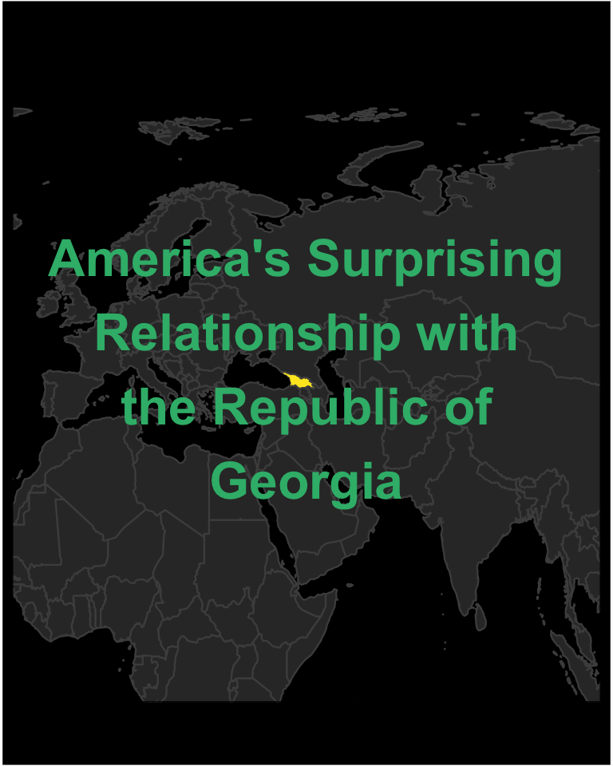

```r
# Renaming region to Country in world_df for pairing purposes
postSoviet_map <- world_df |>
    mutate(`Country Name` = region)

# Making the DF more specific
postSoviet_map <- postSoviet_map |>
    filter(`Country Name` %in% Georgia)



russia_dat <- world_df |>
  filter(!region %in% Georgia)

georgia_lon <- 43.5
georgia_lat <- 42.1


# Now for the actual visual
p3 <- ggplot(postSoviet_map, aes(x = long,
                           y = lat,
                           group = group)) +
   geom_polygon(color = "gray40", fill = "#FDE725", linewidth = .1) +
   geom_polygon(
    data = russia_dat,
    aes(x = long, y = lat, group = group),
    fill = "gray20",
    color = "gray30",
    linewidth = 0.4
  ) +

  annotate( # This is what I use to write the title
    "text",
    x = 45,
    y = 44,
    label = "America's Surprising\nRelationship with\nthe Republic of\nGeorgia",
    color = "#35B779",
    alpha = 1,
    fill = NA,
    fontface = "bold",
    size = 8.5,
    label.size = 0.25
  ) +
        coord_quickmap(
          xlim = c(-10, 100),
          ylim = c(0, 90)) +

   theme(

          panel.grid = element_blank(),

          axis.ticks = element_blank(),
          axis.title = element_blank(),
          axis.text = element_blank(),

          panel.background = element_rect(fill = "black"),
          panel.border = element_rect(color = "black", fill = NA),

          strip.background = element_rect(fill = "black"),
          strip.text = element_text(face = "bold", color = "black"),

          plot.background = element_rect(fill = "black"),
          plot.margin = margin(t = 10, r = 5, b = 30, l = 5, unit = "pt"),
          plot.title = element_text(size = 25, hjust = 0.5, vjust = 0.95, fontface = "bold", color = "white"),
    plot.subtitle = element_text(size = 12, hjust = 0.5, vjust = 0.85, color = "gray80"),


          legend.position = "none",

              )
p3
```

```r
ggsave(filename = here("Final_Project", "www", "Title.png"), plot = p3, width = 4, height = 5, units = "in", dpi = 300)
```

```r
# TEXT SLIDE 1

# I already had the map coded, so to make a solid black background for my text slides, I just turned everything on the map black.

# Loading the environment pointer
data("worldMapEnv", package = "maps")

# Extracting the world polygons as a data frame
world_map <- maps::map("world", plot = F, fill = T)

class(world_map)
```

```
## [1] "map"
```

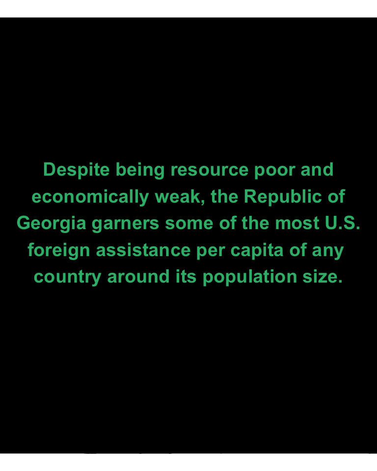

```r
# Map Polygons
world_df <- map_data("world")


# Making a black background
p3 <- ggplot(world_df, aes(x = long,
                           y = lat,
                           group = group)) +
   geom_polygon(color = "black", fill = "black") +

  annotate( # This is what I use to write my short descriptions
    "text",
    x = 45,
    y = 48,
    label = "Despite being resource poor and\neconomically weak, the Republic of\nGeorgia garners some of the most U.S.\nforeign assistance per capita of any \ncountry around its population size.",
    color = "#35B779",
    alpha = 1,
    fill = NA,
    fontface = "bold",
    size = 5,
    label.size = 0.25
  ) +
        coord_quickmap(
          xlim = c(-10, 100),
          ylim = c(0, 90)) +

   theme(

          panel.grid = element_blank(),

          axis.ticks = element_blank(),
          axis.title = element_blank(),
          axis.text = element_blank(),

          panel.background = element_rect(fill = "black"),
          panel.border = element_rect(color = "black", fill = NA),

          strip.background = element_rect(fill = "black"),
          strip.text = element_text(face = "bold", color = "black"),

          plot.background = element_rect(fill = "black"),
          plot.margin = margin(t = 0, r = 0, b = 0, l = 0, unit = "pt"),


          legend.position = "none",

              )
p3
```

```r
ggsave(filename = here("Final_Project", "www", "Text1.png"), plot = p3, width = 4, height = 5, units = "in", dpi = 300)
```

```r
# TEXT SLIDE 2

# Loading the environment pointer
data("worldMapEnv", package = "maps")

# Extracting the world polygons as a data frame
world_map <- maps::map("world", plot = F, fill = T)

class(world_map)
```

```
## [1] "map"
```

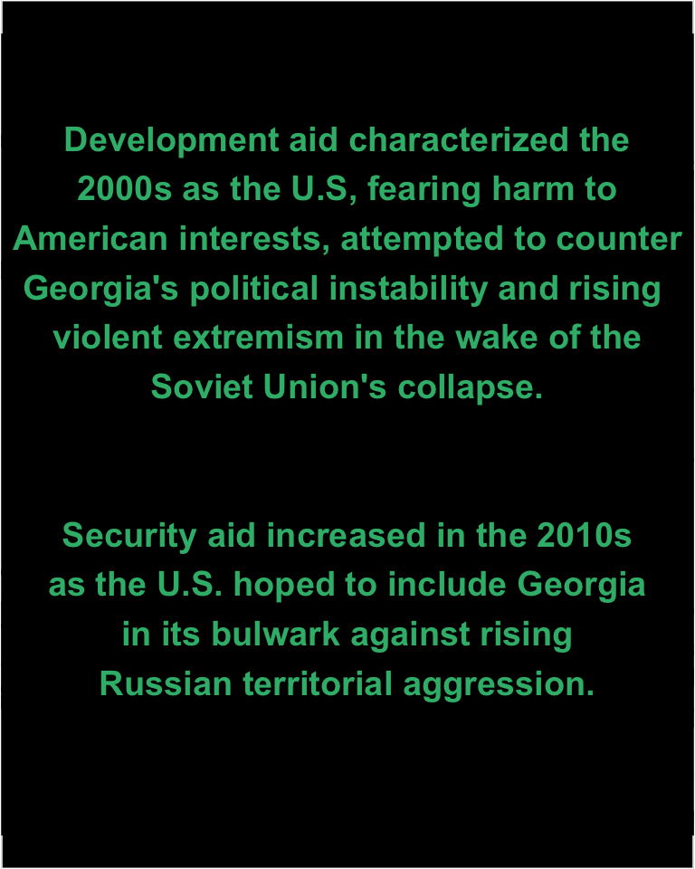

```r
# Map Polygons
world_df <- map_data("world")


# Making a black background
p3 <- ggplot(world_df, aes(x = long,
                           y = lat,
                           group = group)) +
   geom_polygon(color = "black", fill = "black") +

  annotate(
    "text",
    x = 45,
    y = 48,
    label = "Development aid characterized the\n2000s as the U.S, fearing harm to\nAmerican interests, attempted to counter\nGeorgia's political instability and rising \nviolent extremism in the wake of the\nSoviet Union's collapse.\n\n\nSecurity aid increased in the 2010s\nas the U.S. hoped to include Georgia\nin its bulwark against rising\nRussian territorial aggression.",
    color = "#35B779",
    alpha = 1,
    fontface = "bold",
    size = 5,
  ) +
        coord_quickmap(
          xlim = c(-10, 100),
          ylim = c(0, 90)) +

   theme(

          panel.grid = element_blank(),

          axis.ticks = element_blank(),
          axis.title = element_blank(),
          axis.text = element_blank(),

          panel.background = element_rect(fill = "black"),
          panel.border = element_rect(color = "black", fill = NA),

          strip.background = element_rect(fill = "black"),
          strip.text = element_text(face = "bold", color = "black"),

          plot.background = element_rect(fill = "black"),
          plot.margin = margin(t = 14, r = 0, b = 14, l = 0, unit = "pt"),


          legend.position = "none",

              )

p3
```